# Probability with Continuous Random Variables

February 05, 2019

## Obligatory Disclosure

- Ben is an employee of Columbia University, which has received several research grants to develop Stan
- Ben is also a manager of GG Statistics LLC, which uses Stan for business purposes
- According to Columbia University [policy](https://research.columbia.edu/content/conflict-interest-and-research), any such employee who has any equity stake in, a title (such as officer or director) with, or is expected to earn at least \(\$5,000.00\) per year from a private company is required to disclose these facts in presentations
- But you should install the C++ toolchain and RStan R package anyway; see https://github.com/stan-dev/rstan/wiki/RStan-Getting-Started

## Hypergeometric Confusion

- The hypergeometric distribution corresponds to sampling WITHOUT replacement and has PMF \(\Pr\left(\left.x\right|N,K,n\right) = {K \choose x}{N - K \choose n - x}{N \choose n}^{-1}\) where
  - \(N\) is the (finite) size of the set being drawn from
  - \(K\) is the number of successes in that finite set
  - \(n\) is the number of times you draw without replacement
- The `dhyper` function in R parameterizes the hypergeometric PMF differently:
  - `x` is the number of successes sought in `k` draws
  - `m` is the number of successes in the set (deck, urn, etc.)
  - `n` is the number of failures in the set (deck, urn, etc.)
  - `k` is the number of times you draw from the set
- The probability of being dealt, for example, two tens from a deck is just `dhyper(x = 2, m = 4, n = 52 - 4, k = 2)` \(\approx 0.004525\)

## Probability and Cumulative Mass Functions

- \(\Pr\left(\left.x\right|\boldsymbol{\theta}\right)\) is a Probability Mass Function (PMF) over a discrete \(\Omega\) that may depend on some parameter(s) \(\boldsymbol{\theta}\) and the Cumulative Mass Function (CMF) is \(\Pr\left(\left.X\leq x\right|\boldsymbol{\theta}\right)=\sum\limits_{i = \min\{\Omega\} }^x\Pr\left(\left.i\right|\boldsymbol{\theta}\right)\)
- In the first roll of bowling, some simplification implies \(\Pr\left(X\leq x\right) = \frac{ -1 + \mathcal{F}_{x+2}}{- 1 + \mathcal{F}_{n+2}}\)

```r
source("https://tinyurl.com/y93srfmp") # code from week 1 to define F() and Omega
CMF <- function(x, n = 10) return( (- 1 + F(x + 2)) / (- 1 + F(n + 2)) )
round(CMF(Omega), digits = 4)
```

```
##      0      1      2      3      4      5      6      7      8      9     10
## 0.0043 0.0086 0.0172 0.0302 0.0517 0.0862 0.1422 0.2328 0.3793 0.6164 1.0000
```

- How do we know this CMF corresponds to our PMF \(\Pr\left(\left.x\right|n\right) = \frac{\mathcal{F}_{x}}{- 1 + \mathcal{F}_{n+2}}\)?

## PMF is the Rate of Change in the CMF

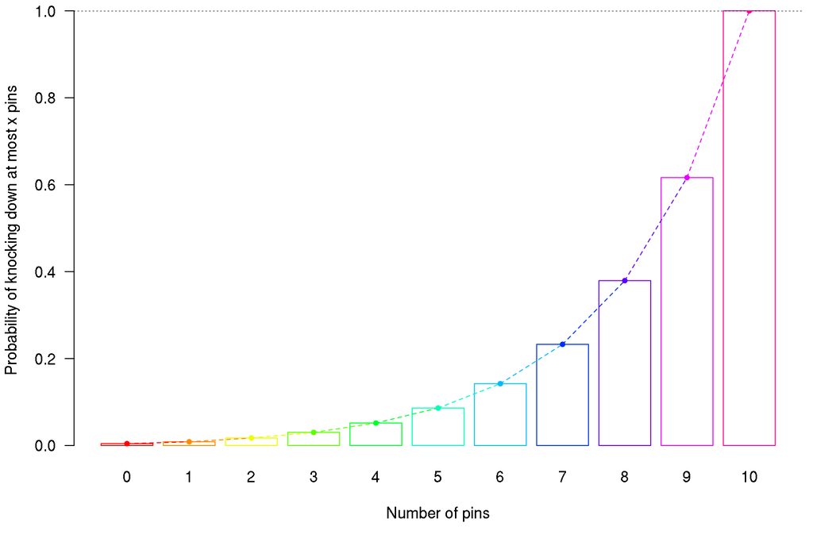

## Cumulative Density Functions

- Now \(\Omega\) is an interval; e.g. \(\Omega=\mathbb{R}\), \(\Omega=\mathbb{R}_{+}\), \(\Omega=\left(a,b\right)\), etc.
- \(\Omega\) has an infinite number of points, so \(\Pr\left(X = x\right) \downarrow 0\)
- \(\Pr\left(X\leq x\right)\) is called the Cumulative Density Function (CDF) from \(\Omega\) to \(\left(0,1\right)\)
- No conceptual difference between a CMF and a CDF except emphasis on whether \(\Omega\) is discrete or continuous so we use \(F\left(\left.x\right|\boldsymbol{\theta}\right)\) for both

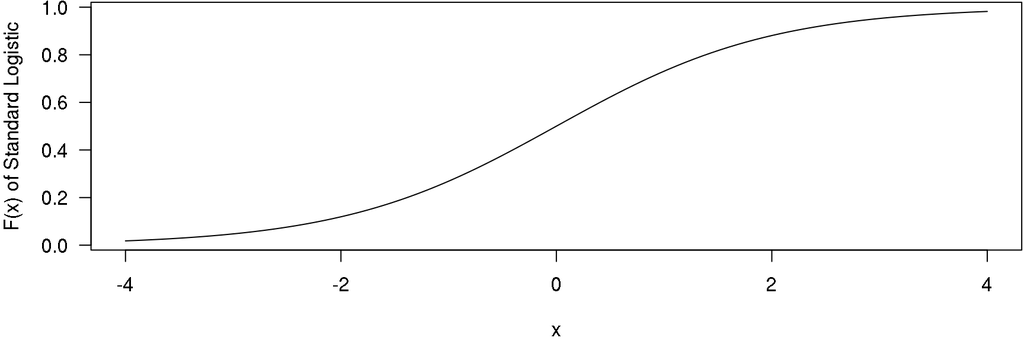

## The Standard Logistic CDF and PDF

- E.g., CDF of the standard logistic distribution over \(\Omega = \mathbb{R}\) is \(F\left(x\right) = \frac{1}{1+e^{-x}}\)
- \(\Pr\left(a<X\leq x\right)=F\left(\left.x\right|\boldsymbol{\theta}\right)-F\left(\left.a\right|\boldsymbol{\theta}\right)\) as in the discrete case
- If \(x=a+h\), \(\frac{F\left(\left.x\right|\boldsymbol{\theta}\right)-F\left(\left.a\right|\boldsymbol{\theta}\right)}{x-a}=\frac{F\left(\left.a+h\right|\boldsymbol{\theta}\right)-F\left(\left.a\right|\boldsymbol{\theta}\right)}{h}\) is the slope of a line segment
- If we then let \(h\downarrow0\), \(\frac{F\left(\left.a+h\right|\boldsymbol{\theta}\right)-F\left(\left.a\right|\boldsymbol{\theta}\right)}{h}\rightarrow\frac{\partial F\left(\left.a\right|\boldsymbol{\theta}\right)}{\partial a}\equiv f\left(\left.x\right|\boldsymbol{\theta}\right)\) is still the RATE OF CHANGE in \(F\left(\left.x\right|\boldsymbol{\theta}\right)\) at \(x\)
- The derivative of the CDF \(F\left(x\right)\) is called the Probability Density Function (PDF) and denoted \(f\left(x\right)\), which is always positive because the CDF increases
- \(f\left(x\right)\) is NOT a probability but is used like a PMF
- What is slope of \(F\left(x\right) = \frac{1}{1 + e^{-x}}\) at \(x\)?
- [Answer](https://www.wolframalpha.com/input/?i=partial+derivative): \(\frac{\partial}{\partial x}F\left(x\right) = \frac{-1}{\left(1+e^{-x}\right)^2} \times \frac{\partial}{\partial x}e^{-x} = \frac{-e^{-x}}{\left(1+e^{-x}\right)^2} \times \frac{\partial -x}{\partial x} = \frac{e^{-x}}{\left(1+e^{-x}\right)^2} \geq 0\)

## The Standard Normal CDF and Its Slope

Standard normal CDF over \(\Omega = \mathbb{R}\) is \(\Phi(x) = \frac{1}{2} + \phi\left(x\right) S\left(x\right)\) where \(\phi\left(x\right) = \frac{1}{\sqrt{2\pi}}e^{-\frac{x^2}{2}}\), \(S\left(x\right) = \sum_{n=0}^\infty \frac{x^{2n+1}}{\left(2n + 1\right)!!}\), and \(a!!\) is the “double factorial” function for a non-negative integer \(a\) such that \(0!! = 1\), \(1!! = 1\), and else \(a!! = a \times \left(a - 2\right)!!\). What is the slope of \(\Phi\left(x\right)\) at \(x\)?

- \[\frac{\partial}{\partial x}\Phi\left(x\right) = \phi\left(x\right) S^\prime\left(x\right) + \phi^\prime\left(x\right) S\left(x\right) = \phi\left(x\right)\sum_{n=0}^\infty \frac{\left(2n + 1\right)x^{2n}}{\left(2n + 1\right)!!} -\\ \phi\left(x\right)x\sum_{n=0}^\infty \frac{x^{2n+1}}{\left(2n + 1\right)!!} = \phi\left(x\right)\sum_{n=0}^\infty \frac{\left(2n + 1\right)x^{2n} - x^{2n+2}}{\left(2n + 1\right)!!} =\\ \phi\left(x\right) \left(\frac{1 - x^2}{1}+\frac{3x^2 - x^4}{3 \times 1} + \frac{5x^4 - x^6}{5\times3\times1} \dots\right) = \phi\left(x\right)\]

## CDF and PDF of the Standard Normal Distribution

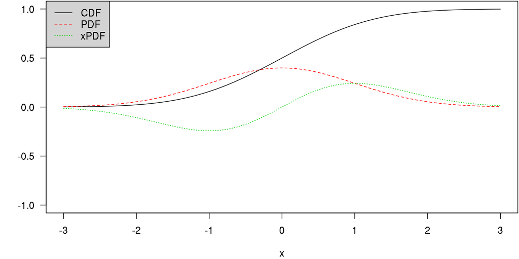

```r
curve(pnorm(x), from = -3, to = 3, ylim = c(-1,1), ylab = "") # CDF; what is the median?
curve(dnorm(x), add = TRUE, col = "red", lty = "dashed")      # PDF; what is the mode?
curve(x * dnorm(x), add = TRUE, col = 3, lty = "dotted")      # g function being integrated
legend("topleft", legend = c("CDF", "PDF", "xPDF"), col = 1:3, lty = 1:3, bg = "lightgrey")
```

## Expectations of Functions of a Continuous RV

- Let \(g\left(X\right)\) be a function of a continuous \(X \in \Omega\)
- The probability that \(X\) is in the interval \(\left[x,x+dx\right]\) is \(f\left(\left.x\right|\boldsymbol{\theta}\right)dx\) where \(dx\) is essentially the smallest non-neglible piece of \(X\)
- The expectation of \(g\left(X\right)\), if it exists (which it may not), is defined as \[\mathbb{E}g\left(X\right) = \int_{\min \Omega}^{\max \Omega} g\left(x\right)f\left(\left.x\right|\boldsymbol{\theta}\right)dx = G\left(\boldsymbol{\theta}\right)\bigg\rvert_{x = \min \Omega}^{x = \max \Omega}\]
- [Integrals](https://www.wolframalpha.com/input/?i=definite+integral) are usually impossible but we can use simulations to approximate them arbitrarily well. Still need to understand integrals conceptually as area.
- Columbia students can [download](https://cuit.columbia.edu/content/mathematica) Mathematica for free
- If \(g\left(X\right)=X\), \(\mathbb{E}X=\mu\) is “the” expectation and if \(g\left(X\right)=\left(X-\mu\right)^{2}\), \(\mathbb{E}\left[\left(X-\mu\right)^{2}\right]=\mathbb{E}\left[X^2\right] - \mu^2\) \(= \sigma^{2}\) is the variance

## Shift and Scale Transformations

- If \(Z\) is distributed standard normal & \(X\left(Z\right) = \mu + \sigma Z\), what’s the PDF of \(X\)?
- Answer: Note that \(Z\left(X\right) = \frac{X - \mu}{\sigma}\). Since this is a monotonic transformation \[\Pr\left(X\leq x\right) = \Pr\left(Z\leq z\left(x\right)\right) = \Phi\left(z\left(x\right)\right) \\ \frac{\partial}{\partial{x}}\Phi\left(z\left(x\right)\right) = \frac{\partial \Phi\left(z\right)}{\partial{z}} \times \frac{\partial z\left(x\right)}{\partial{x}} = \phi\left(z\left(x\right)\right) \frac{1}{\sigma} = \frac{1}{\sigma\sqrt{2\pi}}e^{-\frac{1}{2}\left(\frac{x - \mu}{\sigma}\right)^2}\]
- \(\mathbb{E}X = \mu + \sigma \mathbb{E}Z = \mu\) and \(\mathbb{E}\left[\left(X - \mu\right)^2\right] = \mathbb{E}\left[\left(\sigma Z\right)^2\right] = \sigma^2\mathbb{E}\left[Z^2\right] = \sigma^2\)
- Thus, \(f\left(\left.x\right|\mu,\sigma\right) = \frac{1}{\sigma\sqrt{2\pi}}e^{-\frac{1}{2}\left(\frac{x - \mu}{\sigma}\right)^2}\) is the PDF of the general normal distribution with expectation \(\mu\) and standard deviation \(\sigma\) as parameters
- The normal distribution is one of several in the location-scale family, where such transformations only change the location and scale of the distribution

## Nonlinear but Monotonic Transformations

- If \(Z\) is distributed normal with expectation \(\mu\) and standard deviation \(\sigma\) and \(X\left(Z\right) = e^Z\), what is the PDF of \(X\)? Hint: \(\Pr\left(X \leq x\right) = \Pr\left(Z \leq z\left(x\right)\right)\)
- Answer: Note that \(Z\left(X\right) = \ln X\) and \(\frac{\partial}{\partial x}z\left(x\right) = \frac{1}{x}\) so \(f_X\left(\left.x\right|\mu,\sigma\right) = f_Z\left(\left.z\left(x\right)\right|\mu,\sigma\right) \times \frac{\partial}{\partial x}z\left(x\right) = \frac{1}{x\sigma\sqrt{2\pi}}e^{-\frac{1}{2}\left(\frac{\ln\left(x\right)- \mu}{\sigma}\right)^2}\) is the PDF of the lognormal distribution over \(\Omega = \mathbb{R}_+\)
- \(\mu\) and \(\sigma\) are parameters but NOT the expectation and standard deviation of \(X\), due to the nonlinearity of the antilog transformation. It can be shown that \(\mathbb{E}X = e^{\mu + \frac{1}{2}\sigma^2}\) and \(\mathrm{Var}\left(X\right) = \left(-1 + e^{\sigma^2}\right)e^{2\mu + \sigma^2}\).

## Scale Transformations of Exponential Variates

- Standard exponential distribution over \(\Omega = \mathbb{R}_+\) has CDF \(F\left(x\right) = 1 - e^{-x}\)
- Its PDF is obviously \(f\left(x\right) = \frac{\partial}{\partial x}F\left(x\right) = e^{-x}\), which must integrate to \(1\)
- \(\mathbb{E}X = \int_{0}^\infty xe^{-x}dx = -\left(x+1\right)e^{-x} \bigg\rvert_{x = 0}^{x \rightarrow \infty} \rightarrow -\infty e^{-\infty} + e^{0} \rightarrow 1\)
- What is \(\mathrm{Var}\left(X\right)\)?
- \(\int_{0}^\infty \left(x - 1\right)^2 e^{-x}dx = \int_{0}^\infty x^2 e^{-x}dx - 2\int_{0}^\infty xe^{-x}dx + \int_{0}^\infty e^{-x}dx =\\ -\left(x^2 + 2x + 2\right)e^{-x}\bigg \rvert_{x = 0}^{x \rightarrow \infty} - 2 \times 1 + 1 \rightarrow 1\)
- If \(X\) is distributed standard exponential and \(Y = \mu X\), what is the PDF of \(Y\)?
- Answer: \(\Pr\left(X\leq x\right) = \Pr\left(Y \leq y\left(x\right)\right)\), so \(f\left(\left.y\right|\mu\right) = \frac{\partial 1 - e^{-\frac{y}{\mu}}}{\partial y} = \frac{1}{\mu}e^{-\frac{y}{\mu}}\)
- You will often see this with the substitution \(\lambda = \frac{1}{\mu}\). What are \(\mathbb{E}Y\) & \(\mathrm{Var}\left(Y\right)\)?

## Bivariate Normal Distribution

If \(\Pr\left(\left.X \leq x \bigcap Y \leq y\right|\boldsymbol{\theta}\right) = F\left(\left.x,y\right|\boldsymbol{\theta}\right)\) is a biviariate CDF, then the bivariate PDF is \(\frac{\partial^2}{\partial x \partial y}F\left(\left.x,y\right|\boldsymbol{\theta}\right)\). This generalizes beyond two dimensions. The PDF of the bivariate normal distribution over \(\Omega = \mathbb{R}^2\) has five parameters: \[f\left(\left.x,y\right|\mu_X,\mu_Y,\sigma_X,\sigma_Y,\rho\right) =\\ \frac{1}{2\pi\sigma_X\sigma_Y\sqrt{1-\rho^2}}e^{-\frac{1}{2\left(1-\rho^2\right)} \left(\left(\frac{x - \mu_X}{\sigma_X}\right)^2 + \left(\frac{y - \mu_Y}{\sigma_Y}\right)^2 - 2\rho\frac{x - \mu_X}{\sigma_X}\frac{y - \mu_Y}{\sigma_Y}\right)} = \\ \frac{1}{\sigma_X\sqrt{2\pi}}e^{-\frac{1}{2}\left(\frac{x - \mu_X}{\sigma_X}\right)^2} \times \frac{1}{\color{blue}{\sigma_Y\sqrt{1-\rho^2}}\sqrt{2\pi}}e^{-\frac{1}{2} \left(\frac{y - \left(\color{red}{\mu_y + \frac{\sigma_X}{\sigma_Y}\rho\left(x-\mu_x\right)}\right)} {\color{blue}{\sigma_Y\sqrt{1-\rho^2}}}\right)^2},\] where the first term is a marginal normal PDF and the second is a conditional normal PDF w/ parameters \(\color{red}{\mu = \mu_Y + \frac{\sigma_X}{\sigma_Y}\rho\left(x-\mu_x\right)}\) & \(\color{blue}{\sigma = \sigma_Y\sqrt{1-\rho^2}}\).

## Where Is this Class Going?

- We usually think of parameters as being continuous but contained in a parameter (sub)space \(\Theta\)
- If you cut a continuous RV into a categorical RV, you could apply Bayes Rule
- If you take the limit as the number of cuts \(\uparrow \infty\) you get Bayes Rule for continuous random variables \[f\left(\left.\theta\right|y,a,b\right) = \frac{ f\left(\left.\theta\right|a,b\right) f\left(\left.y\right|\theta\right)} {f\left(\left.y\right|a,b\right)}\]
- Iff you have data, \(y\), then \(L\left(\theta;y\right)\) is the same expression as \(f\left(\left.y\right|\theta\right)\) but is a mathematical function of \(\theta\) called the likelihood function that can be evaluated at any \(\theta \in \Theta\) but only at the OBSERVED \(y\)
- By choosing functions for the numerator, you can (in principle) work out what \(f\left(\left.y\right|a,b\right) = \int_{\Theta}f\left(\left.\theta\right|a,b\right)L\left(\theta;y\right)d\theta\) evaluates to complete Bayes Rule